# Can you prove that orangutans use the wildlife corridor?

Lukmann Haqeem

01 November, 2021

Probably the best approach to monitor orangutan movement is to fit a GPS tracking device on the animal. However, finding a single animal can be very challenging. Moreover, this method often involves shooting the animal from tree with the tranquilizer, the animal could fall to the ground and get injured or even die. Even if safe capture is possible and surveyors can fit tracker on the animal, there is also concern that the animal will grab and remove the tracker out because it is just too nimble and too strong (Trayford and Farmer 2012). Perhaps a safer approach to monitor movement is to follow the animal wherever it goes and records its position regularly with a GPS device (Ancrenaz, Calaque, and Lackman-Ancrenaz 2004). While it is easy for orangutan to move from point to point through canopy at the swampy area, following the animal from the ground can be difficult. There is a good chance that surveyors could not catch up with the animal and lose sight of it during the follow.

Surveying orangutan nest is much easier than the animal itself, and many surveyors actually preferred this approach. The question is, can we use the nest as a proxy for monitoring animal movement? Since orangutan leaves a trail of nests as it moves through the forest, it might be possible to trace the animal’s movement pattern. IF new and unmarked nests are found during a repeat visit at the transects, we can assume that the animal had re-located or moved since the last visit. Also, because new nests are built daily we would expect to see somewhat active movement by the animal throughout the study period.

Load the ‘environment.’

```r
    load("study_area.RData")
    head(study_area)
```

```
##   id x y elevation   forest
## 1  1 1 1 -1.118972 1.112337
## 2  2 1 2 -1.118961 1.112361
## 3  3 1 3 -1.118942 1.112378
## 4  4 1 4 -1.118917 1.112388
## 5  5 1 5 -1.118885 1.112391
## 6  6 1 6 -1.118847 1.112388
```

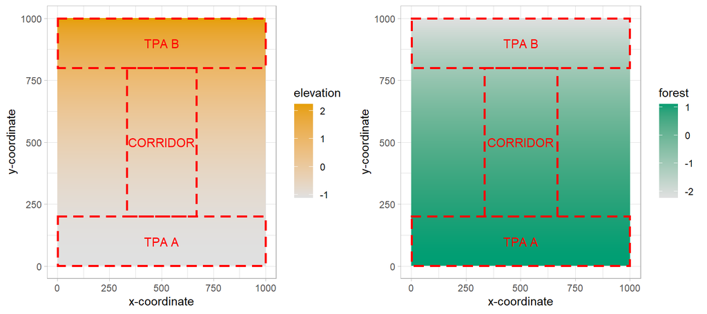

Load the ‘observations.’

```r
    load("nest_data.RData")
    head(data)
```

```
##    id   x   y elevation     forest count session
## 13 13 106 703 0.5374996 -0.5356420     1       A
## 55 55 420 709 0.5658857 -0.5640967     4       A
## 29 29 277 712 0.5801691 -0.5784154     4       A
## 71 71 550 719 0.6137317 -0.6120625     5       A
## 19 19 216 721 0.6233813 -0.6217368     3       A
## 17 17 295 732 0.6769331 -0.6754294     4       A
```

Because we wanted to know whether the orangutans move between the TPAs, we need to survey areas adjacent to the proposed wildlife corridor, including the TPAs. This is to verify whether 1) the animals used the TPAs recently and 2) the animals not using different pathways to go across the TPAs. The transect spacing is the average daily distance range of adult orangutans (Davies et al. 2017; Oram 2018) or shorter to increase nest detection. The survey interval is long enough to allow the animals to roam around and build new nest clusters at different locations. The surveys must be done at least three times for consistency (~Law of averages). Since we are interested in the re-distribution of nests, all nest classes will be recorded. More importantly, we want all the nests’ GPS coordinates and the tress marked accurately and clearly. If the orangutans do move between the TPAs, we should see new nest clusters popping up inside the proposed corridor at different sampling sessions, like shown below.

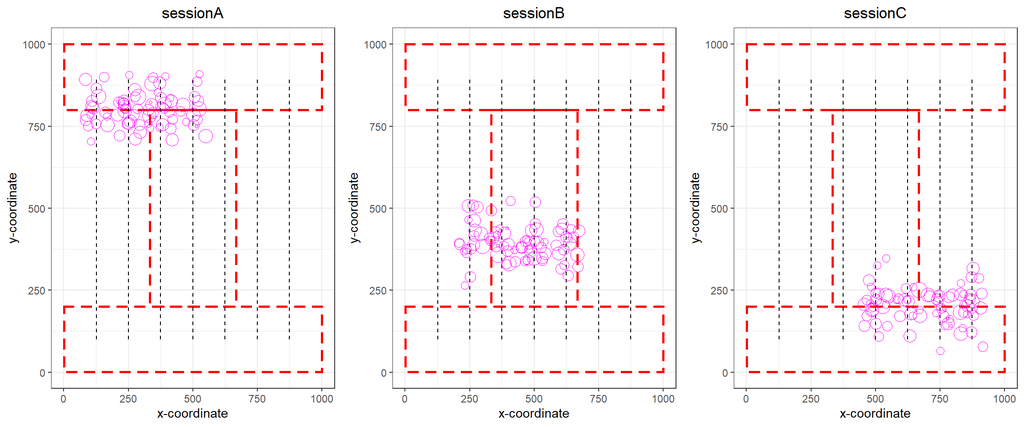

Analyse data. Fit Penalised Regression Splines (PRS) using the gam function in the mgcv package (Wood 2017), and use coefficients from the models to predict count for the entire environment at different phases.

```r
#Fit Penalised Regression Splines (PRS)
fit1 <- gam(count ~ s(x) + s(y), family = poisson, data = data[data$session == "A",])
fit2 <- gam(count ~ s(x) + s(y), family = poisson, data = data[data$session == "B",])
fit3 <- gam(count ~ s(x) + s(y), family = poisson, data = data[data$session == "C",])

#Use coefficients to predict
surveyA <- predict(fit1, type = "response", se.fit = TRUE, newdata = study_area)
surveyB <- predict(fit2, type = "response", se.fit = TRUE, newdata = study_area)
surveyC <- predict(fit3, type = "response", se.fit = TRUE, newdata = study_area)
```

Similar to Species Distribution Modeling (SDM), this analysis tells us which part of the environment will likely have more nests. I think improving the prediction includes using non-Euclidean movement (Sutherland, Fuller, and Royle 2015), rasters that depict anthropogenic influence on the environment (Palminteri et al. 2012; Manduell, Harrison, and Thorpe 2012), and Bayesian analysis (Wade 2000), but I will try out these ideas later when I have more time to run the simulations. Nevertheless, we assume orangutans utilize areas with more nests, and it may be necessary to adjust the proposed wildlife corridor coverage accordingly to include those areas.

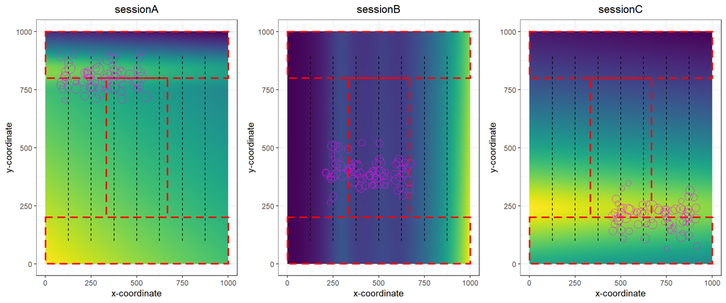

## Questions

should try observations from different sessions should be analysed as one, one set of coefficients. family = binomuil (count > binary) if the study area is big enough and the surveys covers most of the area, we could see how the cluster of nests ‘move’ extend model to include relative distance to human settlements non-Euclidean distance for estimating path of travel (Sutherland, )

## Reference

Ancrenaz, Marc, Romain Calaque, and Isabelle Lackman-Ancrenaz. 2004. “Orangutan Nesting Behavior in Disturbed Forest of Sabah, Malaysia: Implications for Nest Census.” *International Journal of Primatology* 25 (5): 983–1000.

Davies, Andrew B, Marc Ancrenaz, Felicity Oram, and Gregory P Asner. 2017. “Canopy Structure Drives Orangutan Habitat Selection in Disturbed Bornean Forests.” *Proceedings of the National Academy of Sciences* 114 (31): 8307–12.

Manduell, Kirsten L, Mark E Harrison, and Susannah KS Thorpe. 2012. “Forest Structure and Support Availability Influence Orangutan Locomotion in Sumatra and Borneo.” *American Journal of Primatology* 74 (12): 1128–42.

Oram, F. 2018. “Abundance, Feeding and Behavioural Ecology of Orangutans (Pongo Pygmaeus Morio) in the Fragmented Forests of the Kinabatangan Floodplain.” *University Malaysia Sabah (ITBC), Kota Kinabalu, Sabah*, 350.

Palminteri, Suzanne, George VN Powell, Gregory P Asner, and Carlos A Peres. 2012. “LiDAR Measurements of Canopy Structure Predict Spatial Distribution of a Tropical Mature Forest Primate.” *Remote Sensing of Environment* 127: 98–105.

Sutherland, Chris, Angela K Fuller, and J Andrew Royle. 2015. “Modelling Non-Euclidean Movement and Landscape Connectivity in Highly Structured Ecological Networks.” *Methods in Ecology and Evolution* 6 (2): 169–77.

Trayford, Hannah R, and Kay H Farmer. 2012. “An Assessment of the Use of Telemetry for Primate Reintroductions.” *Journal for Nature Conservation* 20 (6): 311–25.

Wade, Paul R. 2000. “Bayesian Methods in Conservation Biology.” *Conservation Biology* 14 (5): 1308–16.

Wood, Simon N. 2017. *Generalized Additive Models: An Introduction with r*. CRC press.